# homework2

Yamei Li, Meirou Guan, Tamires Amorim

9/20/2020

question1: if the dice were fair it means when we roll a die one time, the result could not be 6.So,the probability of being unfair=1/6=16.66% If the dice are unfair, we don’t know what is the probability of fair dice, for example, when six sides both are number 6, the probability of fair dice should be 1. If a die have two sides of number 6, the probability of fair dice should be 2/6. on the other hand, we don’t know what the dice are made of, Is it even or not, all of them can influence the result, the conclusion is that we don’t know the probability of fair dice.

question2: First, we assumed dice is fair and roll dice 30 times, we could compare them to the outcomes we would expect for a fair die,in other words we would expect each number on the die to be rolled about 1/6,so he expect value of the random variable X would be calculated E(X)=np =30* 1/6 =5 Thus,we would expect each number to be rolled about 5 times out of 30 rolls if the die is fair.they obey the binomial distribution, according to binomial distribution, the standard deviation=sqrt(30* 1/6*5/6)=2.04 we need to roll a die for 30 times, the result are follows:

```r
a<-sample(1:6,size=30,replace = T)
print(a)
```

```
##  [1] 4 6 4 4 2 1 6 5 1 2 5 6 5 6 2 1 2 3 6 1 5 2 6 2 2 5 3 2 5 6
```

```r
table(a)
```

```
## a
## 1 2 3 4 5 6
## 4 8 2 3 6 7
```

Although each number did not get rolled exactly 5 times as we predicted,next,we will use a hypothesis to test with statistic. (1)we can write the null and alternative hypotheses as follows: Ho: p1=p2=p3=p4=p5=p6=1/6 Ha: there is some difference amongst the probabilities (2) The sample data are randomly selected, and the np>5 and n(1-p)>5,the condition for a binominal distribution are met,so,we can use chi-square statistic to test.We set the level of significance given in the problem is a=0.05 . (3)We use chi-square to tset:

```r
chisq.test(table(a),p=rep(1/6,6))
```

```
##
##  Chi-squared test for given probabilities
##
## data:  table(a)
## X-squared = 5.6, df = 5, p-value = 0.3471
```

```r
x<-pbinom(5,30,1/6)
print(x)
```

```
## [1] 0.616447
```

this code resuly means the probability of getting 5 or less 6 from 30 roll dice is 0.616447,and we also wirte following code to calculate the probability of the time number 6 comes up equal to 6,7,8. according to the result, we can found that when the times of number 6 comes up increase one time, the probability will decrease a lot.

```r
x<-dbinom(6,30,1/6)
print(x)
```

```
## [1] 0.1600901
```

```r
x<-dbinom(7,30,1/6)
print(x)
```

```
## [1] 0.1097761
```

```r
x<-dbinom(8,30,1/6)
print(x)
```

```
## [1] 0.06312124
```

```r
a<-sample(1:6,size=30,replace = T)
print(a)
```

```
##  [1] 5 2 2 2 2 4 3 6 5 4 1 4 2 5 6 1 6 2 1 3 6 6 5 5 3 6 4 5 3 4
```

```r
table(a)
```

```
## a
## 1 2 3 4 5 6
## 3 6 4 5 6 6
```

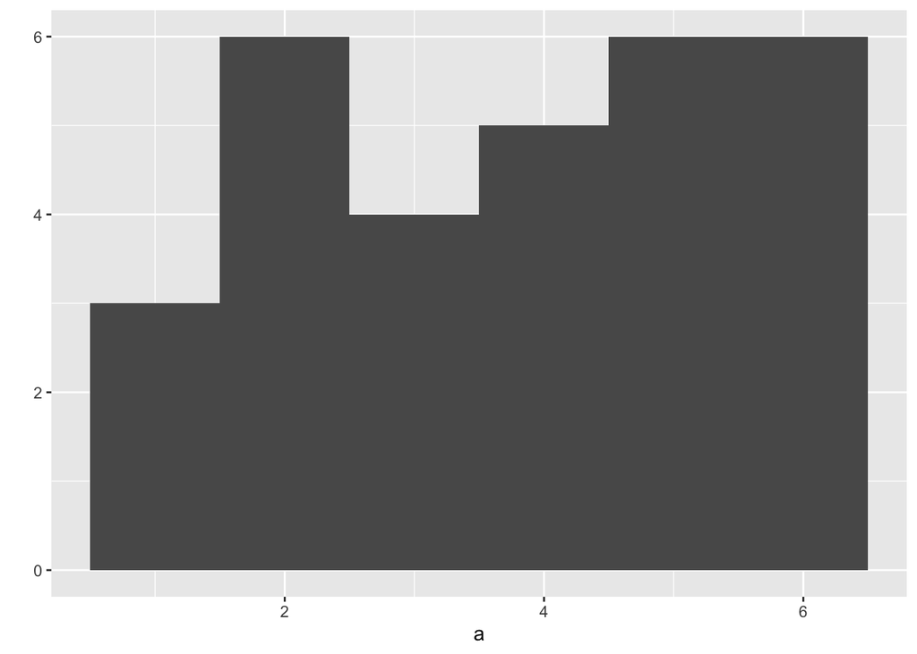

```r
library(ggplot2)
qplot(a,binwidth=1)
```

```r
chisq.test(table(a),p=rep(1/6,6))
```

```
##
##  Chi-squared test for given probabilities
##
## data:  table(a)
## X-squared = 1.6, df = 5, p-value = 0.9012
```

```r
a<-sample(1:6,size=100,replace = T)
print(a)
```

```
##   [1] 1 6 6 4 6 2 1 1 5 1 1 5 2 3 6 1 4 4 2 5 6 1 4 4 3 1 5 5 5 5 5 6 2 1 2 4 3
##  [38] 1 4 3 4 1 5 3 4 5 5 2 6 1 1 2 6 6 5 6 3 4 1 2 5 3 6 6 6 5 1 6 3 1 2 4 1 3
##  [75] 6 5 4 4 1 4 3 5 6 4 1 3 6 6 2 6 4 3 4 3 6 6 6 2 3 2
```

```r
table(a)
```

```
## a
##  1  2  3  4  5  6
## 19 12 14 17 16 22
```

```r
chisq.test(table(a),p=rep(1/6,6))
```

```
##
##  Chi-squared test for given probabilities
##
## data:  table(a)
## X-squared = 3.8, df = 5, p-value = 0.5786
```

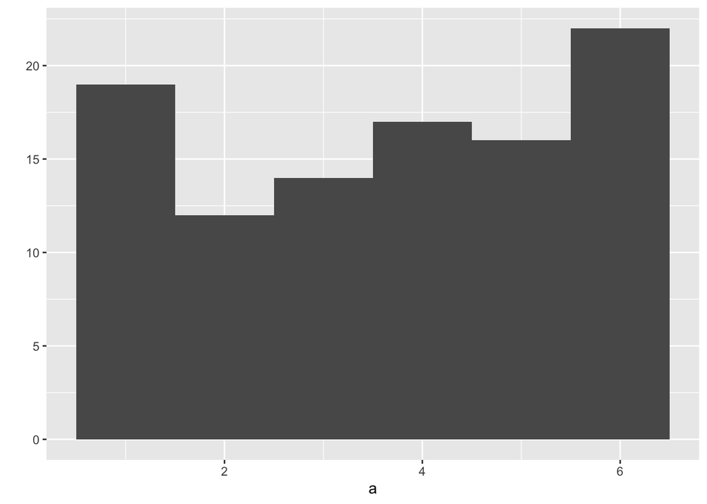

```r
qplot(a,binwidth=1)
```

```r
library(ggplot2)
a<-sample(1:6,size=10000,replace = T)
table(a)
```

```
## a
##    1    2    3    4    5    6
## 1619 1687 1671 1677 1653 1693
```

```r
chisq.test(table(a),p=rep(1/6,6))
```

```
##
##  Chi-squared test for given probabilities
##
## data:  table(a)
## X-squared = 2.2148, df = 5, p-value = 0.8187
```

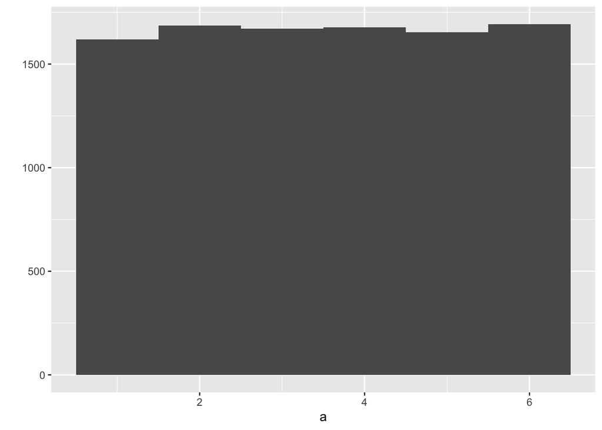

```r
qplot(a,binwidth=1)
```

```r
library(ggplot2)
a<-sample(1:6,size=100000,replace = T)
table(a)
```

```
## a
##     1     2     3     4     5     6
## 17037 16546 16453 16505 16655 16804
```

```r
chisq.test(table(a),p=rep(1/6,6))
```

```
##
##  Chi-squared test for given probabilities
##
## data:  table(a)
## X-squared = 14.55, df = 5, p-value = 0.01247
```

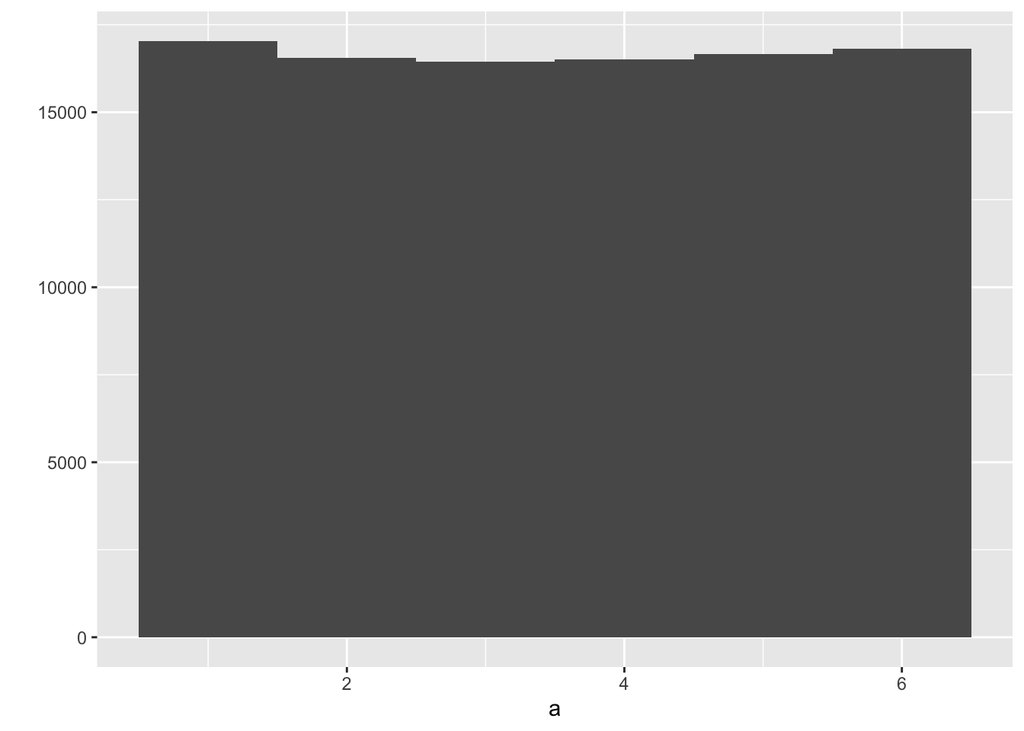

```r
qplot(a,binwidth=1)
```

```r
a<-sample(1:6,size=100,replace = T)
mean(a)
```

```
## [1] 3.44
```